# FINAL Revised Group Project

### **Model 2: best BIC model**

This is a 12-variable model

```r
add.bic <- c()
for(i in 1:59)
{
  if(resforward$which[12,i] == "TRUE")
    add.bic <- c(add.bic, names(crime[i-1]))
}

for(i in 1:length(add.bic))
{
  print(as.symbol(add.bic[i]))
}
```

```
## state
## racePctBlack
## racePctHisp
## pctUrban
## pctWPubAsst
## MalePctDivorce
## PctYoungKids2Par
## PctTeen2Par
## PctLargHouseFam
## HousVacant
## MedRentPctHousInc
## NumStreet
```

```r
fit.bic <- lm(ViolentCrimesPerPop~state+racePctBlack+racePctHisp+pctUrban+pctWPubAsst+MalePctDivorce+PctYoungKids2Par+PctTeen2Par+PctLargHouseFam+HousVacant+MedRentPctHousInc+NumStreet, data=crimeTraining)
summary(fit.bic)
```

```
##
## Call:
## lm(formula = ViolentCrimesPerPop ~ state + racePctBlack + racePctHisp +
##     pctUrban + pctWPubAsst + MalePctDivorce + PctYoungKids2Par +
##     PctTeen2Par + PctLargHouseFam + HousVacant + MedRentPctHousInc +
##     NumStreet, data = crimeTraining)
##
## Residuals:
##      Min       1Q   Median       3Q      Max
## -0.48037 -0.07377 -0.01320  0.04604  0.78762
##
## Coefficients:
##                     Estimate Std. Error t value Pr(>|t|)
## (Intercept)        0.1140713  0.0629044   1.813  0.07007 .
## state             -0.0008827  0.0002884  -3.060  0.00227 **
## racePctBlack       0.3067070  0.0278731  11.004  < 2e-16 ***
## racePctHisp        0.1813831  0.0343091   5.287 1.53e-07 ***
## pctUrban           0.0577860  0.0110924   5.210 2.30e-07 ***
## pctWPubAsst        0.0992086  0.0414572   2.393  0.01689 *
## MalePctDivorce     0.1963264  0.0361377   5.433 6.97e-08 ***
## PctYoungKids2Par  -0.1459744  0.0516766  -2.825  0.00483 **
## PctTeen2Par       -0.0912645  0.0481575  -1.895  0.05836 .
## PctLargHouseFam    0.0406950  0.0444877   0.915  0.36054
## HousVacant         0.1109006  0.0391774   2.831  0.00474 **
## MedRentPctHousInc  0.0713468  0.0305889   2.332  0.01988 *
## NumStreet          0.2528039  0.0534155   4.733 2.53e-06 ***
## ---
## Signif. codes:  0 '***' 0.001 '**' 0.01 '*' 0.05 '.' 0.1 ' ' 1
##
## Residual standard error: 0.1397 on 1000 degrees of freedom
## Multiple R-squared:  0.6559, Adjusted R-squared:  0.6517
## F-statistic: 158.8 on 12 and 1000 DF,  p-value: < 2.2e-16
```

*Residual plots for m2*

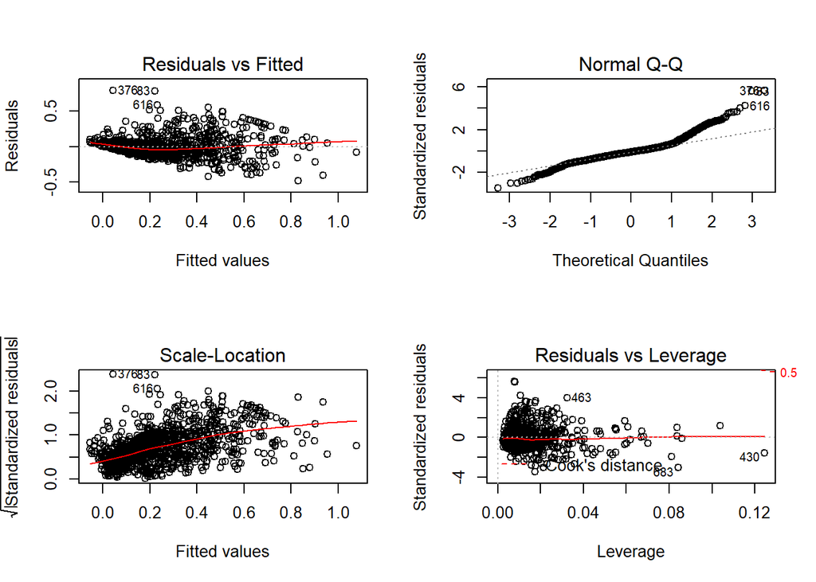

```r
par(mfrow=c(2,2))
plot(fit.bic)
```

**Cp, BIC, and adjusted R-squared**

```r
cat("Cp: ", resforward$cp[12])
```

```
## Cp:  43.54231
```

```r
cat("BIC: ", resforward$bic[12])
```

```
## BIC:  -990.6249
```

```r
cat("adjusted R-squared: ", resforward$adjr2[12])
```

```
## adjusted R-squared:  0.6517371
```

**Validation set error**

```r
mean((predict(fit.bic, newdata=crimeTesting) - crimeTesting$ViolentCrimesPerPop)^2)
```

```
## [1] 0.01894992
```

The validation set error for m2 is 1.895%.

**LOOCV**

```r
glmfit.bic <- glm(ViolentCrimesPerPop~state+racePctBlack+racePctHisp+pctUrban+pctWPubAsst+MalePctDivorce+PctYoungKids2Par+PctTeen2Par+PctLargHouseFam+HousVacant+MedRentPctHousInc+NumStreet, data=crime)
LOOCV.bic <- cv.glm(crime, glmfit.bic)$delta[1]
print(LOOCV.bic)
```

```
## [1] 0.01927082
```

LOOCV gives us a test error of 1.927% for m2.

### **Model 3: best adjusted R-squared**

This is a 36-variable model.

```r
remove.adj <- c()
for(i in 1:59)
{
  if(resforward$which[36,i] == "FALSE")
    remove.adj <- c(remove.adj, names(crime[i-1]))
}

for(i in 1:length(remove.adj))
{
  print(as.symbol(remove.adj[i]))
}
```

```
## fold
## racePctAsian
## agePct12t21
## HispPerCap
## PctLess9thGrade
## PctOccupManu
## MalePctNevMarr
## PctWorkMomYoungKids
## PctWorkMom
## PctImmigRecent
## PctImmigRec10
## PctVacMore6Mos
## MedYrHousBuilt
## PctHousNoPhone
## PctWOFullPlumb
## OwnOccHiQuart
## RentLowQ
## PctBornSameState
## PctSameState85
## LandArea
## PopDens
## PctUsePubTrans
```

```r
fit.adj <- lm(ViolentCrimesPerPop~.-fold-racePctAsian-agePct12t21-HispPerCap-PctLess9thGrade-PctOccupManu-MalePctNevMarr-PctWorkMomYoungKids-PctWorkMom-PctImmigRecent-PctImmigRec10-PctVacMore6Mos-MedYrHousBuilt-PctHousNoPhone-PctWOFullPlumb-OwnOccHiQuart-RentLowQ-PctBornSameState-PctSameState85-LandArea-PopDens-PctUsePubTrans, data=crimeTraining)
summary(fit.adj)
```

```
##
## Call:
## lm(formula = ViolentCrimesPerPop ~ . - fold - racePctAsian -
##     agePct12t21 - HispPerCap - PctLess9thGrade - PctOccupManu -
##     MalePctNevMarr - PctWorkMomYoungKids - PctWorkMom - PctImmigRecent -
##     PctImmigRec10 - PctVacMore6Mos - MedYrHousBuilt - PctHousNoPhone -
##     PctWOFullPlumb - OwnOccHiQuart - RentLowQ - PctBornSameState -
##     PctSameState85 - LandArea - PopDens - PctUsePubTrans, data = crimeTraining)
##
## Residuals:
##      Min       1Q   Median       3Q      Max
## -0.50632 -0.07822 -0.01322  0.05304  0.78898
##
## Coefficients:
##                         Estimate Std. Error t value Pr(>|t|)
## (Intercept)            0.1490461  0.1096790   1.359 0.174483
## state                 -0.0007083  0.0003236  -2.189 0.028859 *
## householdsize          0.0812567  0.0685655   1.185 0.236268
## racePctBlack           0.3155994  0.0299170  10.549  < 2e-16 ***
## racePctHisp            0.1328167  0.0387364   3.429 0.000632 ***
## agePct65up             0.1094486  0.0560882   1.951 0.051299 .
## pctUrban               0.0478779  0.0134589   3.557 0.000393 ***
## pctWFarmSelf          -0.0261917  0.0269437  -0.972 0.331247
## pctWPubAsst            0.1128035  0.0520913   2.165 0.030591 *
## pctWRetire            -0.1150957  0.0424216  -2.713 0.006782 **
## BlackPerCap            0.0436583  0.0359299   1.215 0.224623
## IndianPerCap          -0.0455752  0.0272997  -1.669 0.095351 .
## AsianPerCap            0.0432212  0.0256858   1.683 0.092755 .
## PctUnemployed         -0.0684309  0.0471701  -1.451 0.147177
## PctEmplManu           -0.0521530  0.0309146  -1.687 0.091923 .
## PctEmplProfServ       -0.0880141  0.0395243  -2.227 0.026186 *
## MalePctDivorce         0.1084707  0.0497906   2.179 0.029605 *
## PctYoungKids2Par      -0.1229853  0.0537689  -2.287 0.022392 *
## PctTeen2Par           -0.0905204  0.0519871  -1.741 0.081962 .
## NumIlleg              -0.1509962  0.0913283  -1.653 0.098585 .
## NumImmig              -0.1626854  0.0961873  -1.691 0.091091 .
## PctRecentImmit         0.0478947  0.0340661   1.406 0.160061
## PctLargHouseFam       -0.0397012  0.0630639  -0.630 0.529144
## PersPerRentOccHous     0.0716796  0.0538085   1.332 0.183131
## PctHousLess3BR         0.1091866  0.0694243   1.573 0.116102
## MedNumBR               0.0334177  0.0272282   1.227 0.219998
## HousVacant             0.1293067  0.0649796   1.990 0.046874 *
## PctHousOccup          -0.0563879  0.0370549  -1.522 0.128398
## PctHousOwnOcc         -0.0671590  0.0581266  -1.155 0.248213
## PctVacantBoarded       0.0654779  0.0287431   2.278 0.022940 *
## MedRentPctHousInc      0.1096372  0.0365098   3.003 0.002742 **
## MedOwnCostPctInc      -0.0548526  0.0359365  -1.526 0.127240
## MedOwnCostPctIncNoMtg -0.0728303  0.0297043  -2.452 0.014387 *
## NumInShelters          0.1133069  0.0930541   1.218 0.223653
## NumStreet              0.2985673  0.0686867   4.347 1.53e-05 ***
## PctSameCity85          0.0928367  0.0351861   2.638 0.008461 **
## LemasPctOfficDrugUn    0.0443909  0.0209588   2.118 0.034426 *
## ---
## Signif. codes:  0 '***' 0.001 '**' 0.01 '*' 0.05 '.' 0.1 ' ' 1
##
## Residual standard error: 0.1369 on 976 degrees of freedom
## Multiple R-squared:  0.6775, Adjusted R-squared:  0.6656
## F-statistic: 56.96 on 36 and 976 DF,  p-value: < 2.2e-16
```

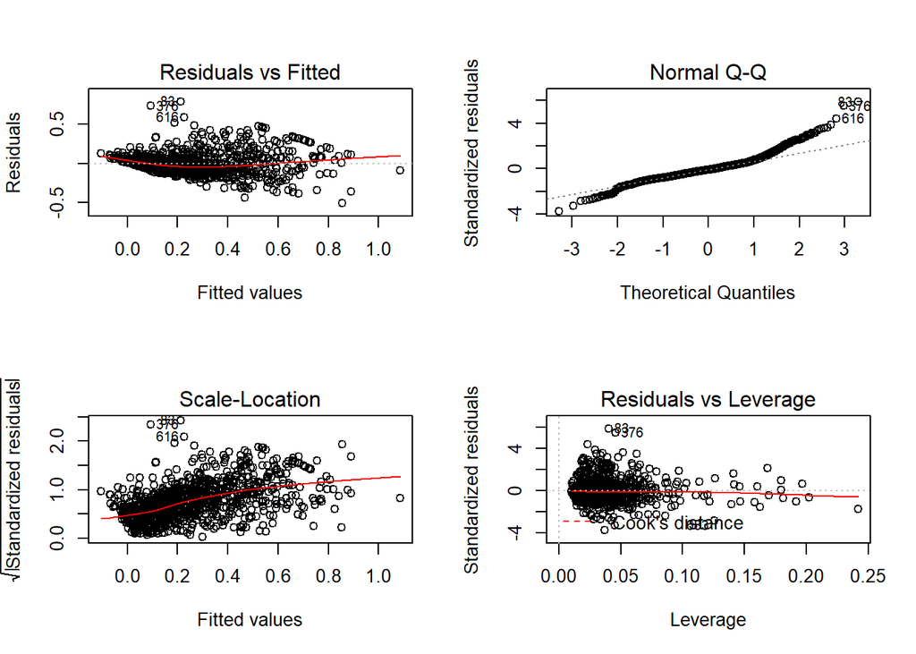

```r
par(mfrow=c(2,2))
plot(fit.adj)
```

**Cp, BIC, and adjusted R-squared**

```r
cat("Cp: ", resforward$cp[36])
```

```
## Cp:  26.71804
```

```r
cat("BIC: ", resforward$bic[36])
```

```
## BIC:  -890.3419
```

```r
cat("adjusted R-squared: ", resforward$adjr2[36])
```

```
## adjusted R-squared:  0.6656187
```

**Validation set error**

```r
mean((predict(fit.adj, newdata=crimeTesting) - crimeTesting$ViolentCrimesPerPop)^2)
```

```
## [1] 0.0190881
```

The validation set error for m3 is 1.909%.

**LOOCV**

```r
glmfit.adj <- glm(ViolentCrimesPerPop~.-fold-racePctAsian-agePct12t21-HispPerCap-PctLess9thGrade-PctOccupManu-MalePctNevMarr-PctWorkMomYoungKids-PctWorkMom-PctImmigRecent-PctImmigRec10-PctVacMore6Mos-MedYrHousBuilt-PctHousNoPhone-PctWOFullPlumb-OwnOccHiQuart-RentLowQ-PctBornSameState-PctSameState85-LandArea-PopDens-PctUsePubTrans, data=crime)
LOOCV.adj <- cv.glm(crime, glmfit.adj)$delta[1]
print(LOOCV.adj)
```

```
## [1] 0.01898466
```

LOOCV gives us a test error of 1.898% for m3.

## Ridge Regression

```r
library(glmnet)
```

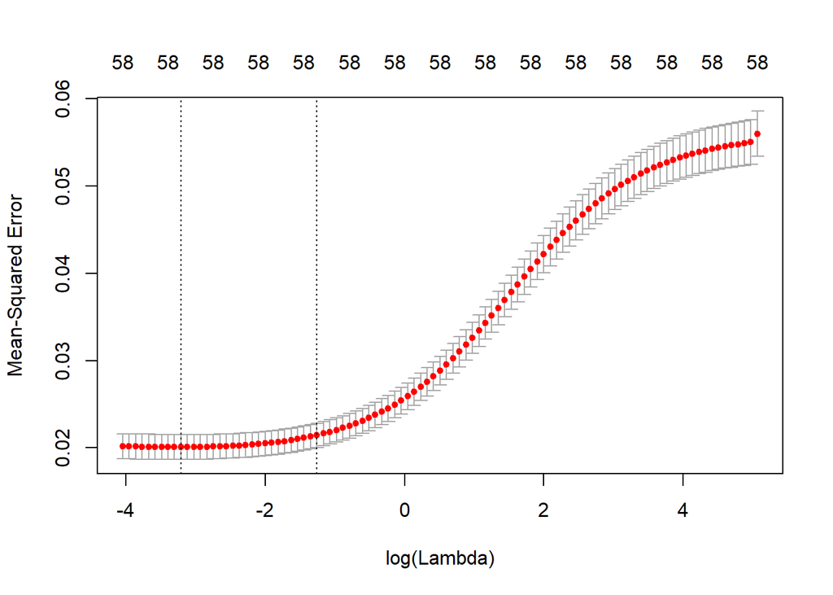

```r
library(foreach)

x <- model.matrix(ViolentCrimesPerPop~., data = crimeTraining)[,-1]
y <- crimeTraining$ViolentCrimesPerPop

set.seed(1)
cv.ridge <- cv.glmnet(x, y, alpha = 0)
bestlam.ridge <- cv.ridge$lambda.min
plot(cv.ridge)
```

```r
ridge.fit <-glmnet(x, y, alpha = 0, lambda = bestlam.ridge)
coef(ridge.fit)
```

```
## 59 x 1 sparse Matrix of class "dgCMatrix"
##                                  s0
## (Intercept)            0.2004533474
## state                 -0.0007726550
## fold                  -0.0001589678
## householdsize          0.0158409858
## racePctBlack           0.2144612337
## racePctAsian           0.0239509601
## racePctHisp            0.0611598543
## agePct12t21           -0.0579121428
## agePct65up             0.0332290540
## pctUrban               0.0430407767
## pctWFarmSelf          -0.0334937346
## pctWPubAsst            0.0600701460
## pctWRetire            -0.0548612982
## BlackPerCap            0.0155320144
## IndianPerCap          -0.0286434612
## AsianPerCap            0.0393665072
## HispPerCap             0.0200147584
## PctLess9thGrade        0.0233421076
## PctUnemployed         -0.0123333082
## PctEmplManu           -0.0477398165
## PctEmplProfServ       -0.0453556401
## PctOccupManu           0.0263790016
## MalePctDivorce         0.0990099246
## MalePctNevMarr         0.0369069570
## PctYoungKids2Par      -0.1093642094
## PctTeen2Par           -0.1207026631
## PctWorkMomYoungKids    0.0417945971
## PctWorkMom            -0.0367022784
## NumIlleg               0.0021562603
## NumImmig              -0.0601874004
## PctImmigRecent         0.0071724138
## PctImmigRec10          0.0241833473
## PctRecentImmit         0.0252240692
## PctLargHouseFam        0.0427482882
## PersPerRentOccHous     0.0582157712
## PctHousLess3BR         0.0599624427
## MedNumBR               0.0159134942
## HousVacant             0.0851751226
## PctHousOccup          -0.0734062502
## PctHousOwnOcc         -0.0404229377
## PctVacantBoarded       0.0674730937
## PctVacMore6Mos        -0.0281413795
## MedYrHousBuilt         0.0053810054
## PctHousNoPhone         0.0330116954
## PctWOFullPlumb         0.0264398386
## OwnOccHiQuart          0.0142802144
## RentLowQ              -0.0392215877
## MedRentPctHousInc      0.0770232044
## MedOwnCostPctInc      -0.0137152235
## MedOwnCostPctIncNoMtg -0.0545118438
## NumInShelters          0.0554856706
## NumStreet              0.1947697046
## PctBornSameState      -0.0012923475
## PctSameCity85          0.0567708964
## PctSameState85         0.0181899941
## LandArea              -0.0149888030
## PopDens               -0.0027578768
## PctUsePubTrans        -0.0037196963
## LemasPctOfficDrugUn    0.0486632030
```

**Validation set error**

```r
xTest <- model.matrix(ViolentCrimesPerPop~., data=crimeTesting)[,-1]
yTest <- crimeTesting$ViolentCrimesPerPop
mean((predict(ridge.fit, s = bestlam.ridge, newx=xTest) - yTest)^2)
```

```
## [1] 0.01894046
```

The validation set error for m4 is 1.894%.

**LOOCV**

```r
loocv.ridge <- c()
for(i in 1:nrow(crime))
{
  x <- model.matrix(ViolentCrimesPerPop~., data = crime[-i,])[,-1]
  y <- crime[-i,]$ViolentCrimesPerPop
  loocv.ridge <- c(loocv.ridge, mean((predict(ridge.fit, s = bestlam.ridge, newx=x) - y)^2))
}

mean(loocv.ridge)
```

```
## [1] 0.01863495
```

LOOCV gives us a test error of 1.863% for m4.

## Lasso Regression

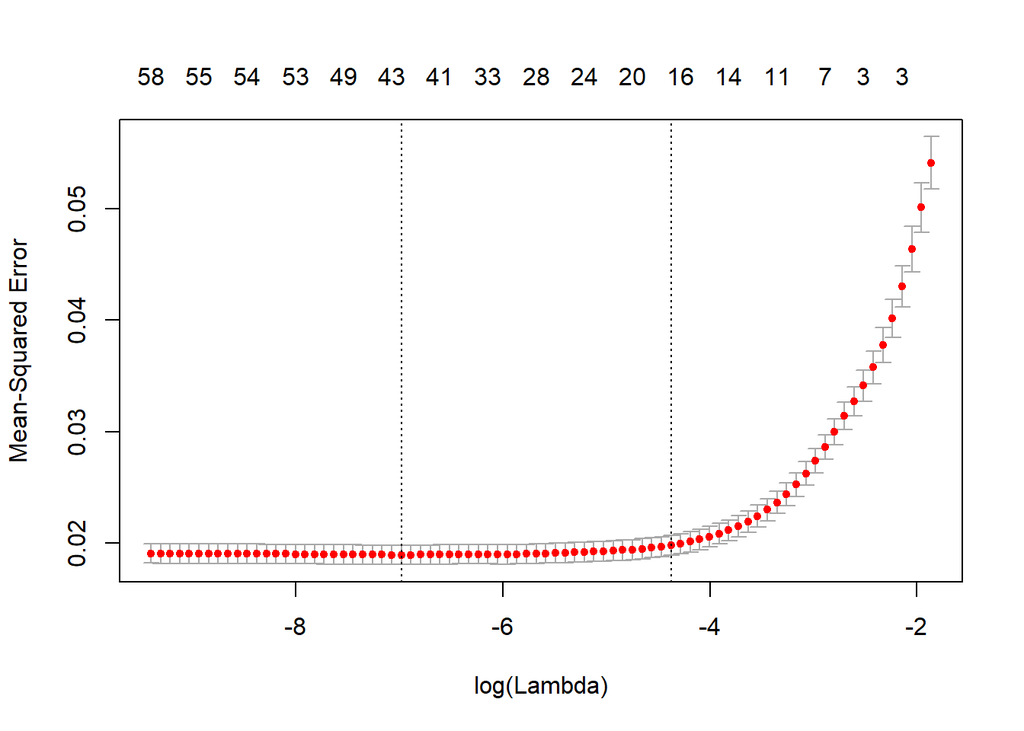

```r
cv.lasso <- cv.glmnet(x, y, alpha = 1)
bestlam.lasso <- cv.lasso$lambda.min
plot(cv.lasso)
```

```r
lasso.fit <- glmnet(x, y, alpha = 1, lambda = bestlam.lasso)
coef.lasso <- predict(lasso.fit, type = "coefficients", s=bestlam.lasso)[1:59,]
coef.lasso[coef.lasso != 0]
```

```
##           (Intercept)                 state                  fold
##           0.232751792          -0.001065353          -0.001211172
##         householdsize          racePctBlack           racePctHisp
##           0.051674247           0.317674083           0.080344303
##           agePct12t21            agePct65up              pctUrban
##          -0.044232051           0.036632020           0.036403188
##           pctWPubAsst            pctWRetire           BlackPerCap
##           0.022578353          -0.054051295          -0.009392863
##          IndianPerCap           AsianPerCap            HispPerCap
##          -0.021284991           0.017378888           0.019982424
##         PctUnemployed           PctEmplManu       PctEmplProfServ
##          -0.026284522          -0.015850705          -0.024507721
##          PctOccupManu        MalePctDivorce        MalePctNevMarr
##           0.023789878           0.142456795           0.048183032
##      PctYoungKids2Par           PctTeen2Par            PctWorkMom
##          -0.150197640          -0.057231635          -0.074140312
##              NumImmig        PctImmigRecent         PctImmigRec10
##          -0.076440824          -0.005489912          -0.002283597
##        PctRecentImmit       PctLargHouseFam    PersPerRentOccHous
##           0.041761110           0.016529372           0.048780108
##        PctHousLess3BR            HousVacant          PctHousOccup
##           0.067302121           0.075560117          -0.079212808
##      PctVacantBoarded        PctVacMore6Mos              RentLowQ
##           0.057862679          -0.039501836          -0.041636476
##     MedRentPctHousInc MedOwnCostPctIncNoMtg         NumInShelters
##           0.054274721          -0.055739136           0.089294968
##             NumStreet         PctSameCity85               PopDens
##           0.171825105           0.057350115           0.020870168
##   LemasPctOfficDrugUn
##           0.026917470
```

**Validation set error**

```r
mean((predict(lasso.fit, s = bestlam.lasso, newx=xTest) - yTest)^2)
```

```
## [1] 0.01745593
```

**LOOCV**

```r
loocv.lasso <- c()
for(i in 1:nrow(crime))
{
  x <- model.matrix(ViolentCrimesPerPop~., data = crime[-i,])[,-1]
  y <- crime[-i,]$ViolentCrimesPerPop
  loocv.lasso <- c(loocv.lasso, mean((predict(lasso.fit, s = bestlam.lasso, newx=x) - y)^2))
}

mean(loocv.lasso)
```

```
## [1] 0.01801492
```